# Content-Based Recommendation Systems

We note here that this system has a clear weakness: If you like a movie from a franchise, recommendations are very likely to come from the same franchise. In general, there is a very limited set of movies to generate the recommendations. This is a consideration for future work on a larger dataset.

This notebook can be found on Kaggle: https://www.kaggle.com/code/alinagdartmouth/movierecommendation-contentbased

```python
# This Python 3 environment comes with many helpful analytics libraries installed
# It is defined by the kaggle/python Docker image: https://github.com/kaggle/docker-python
# For example, here's several helpful packages to load

import numpy as np # linear algebra
import pandas as pd # data processing, CSV file I/O (e.g. pd.read_csv)

# Input data files are available in the read-only "../input/" directory
# For example, running this (by clicking run or pressing Shift+Enter) will list all files under the input directory

import os
for dirname, _, filenames in os.walk('/kaggle/input'):
    for filename in filenames:
        print(os.path.join(dirname, filename))

# You can write up to 20GB to the current directory (/kaggle/working/) that gets preserved as output when you create a version using "Save & Run All"
# You can also write temporary files to /kaggle/temp/, but they won't be saved outside of the current session
```

```
/kaggle/input/imdb-dataset-of-top-1000-movies-and-tv-shows/imdb_top_1000.csv
```

```python
# Create dataset
df_movies = pd.read_csv('/kaggle/input/imdb-dataset-of-top-1000-movies-and-tv-shows/imdb_top_1000.csv')
```

```python
# Info on dataset
df_movies.info()
```

```
<class 'pandas.core.frame.DataFrame'>
RangeIndex: 1000 entries, 0 to 999
Data columns (total 16 columns):
 #   Column         Non-Null Count  Dtype
---  ------         --------------  -----
 0   Poster_Link    1000 non-null   object
 1   Series_Title   1000 non-null   object
 2   Released_Year  1000 non-null   object
 3   Certificate    899 non-null    object
 4   Runtime        1000 non-null   object
 5   Genre          1000 non-null   object
 6   IMDB_Rating    1000 non-null   float64
 7   Overview       1000 non-null   object
 8   Meta_score     843 non-null    float64
 9   Director       1000 non-null   object
 10  Star1          1000 non-null   object
 11  Star2          1000 non-null   object
 12  Star3          1000 non-null   object
 13  Star4          1000 non-null   object
 14  No_of_Votes    1000 non-null   int64
 15  Gross          831 non-null    object
dtypes: float64(2), int64(1), object(13)
memory usage: 125.1+ KB
```

## Data preprocessing

### Missing values

From the information, we note that neither the runtime nor the year of release are integers (but strings instead). So, the first step is to transform the data to integer values for easier handling. There is also one release year missing. We fill the year by looking up the one movie. Since there are more entries missing for the Certificate, the Meta-Score and the Gross, this approach is not feasible here. Instead, we fill the numerical values (Meta-Score and Gross) with the mean of the other movies and the Certificate with a new category: Missing. Further, we drop the link to the poster.

```python
# Replace runtime strings with integer numbers
df_movies['Runtime'] = pd.to_numeric(df_movies['Runtime'].str.replace(' min', ''), errors='coerce')
```

```python
# Translate the string release year to numbers
df_movies['Released_Year'][966] = '1995'

df_movies['Released_Year'] = pd.to_numeric(df_movies['Released_Year'].str.replace(',', ''), errors='coerce')
```

```python
# Find empty data entries
df_movies.isna().sum()
```

```
Poster_Link        0
Series_Title       0
Released_Year      0
Certificate      101
Runtime            0
Genre              0
IMDB_Rating        0
Overview           0
Meta_score       157
Director           0
Star1              0
Star2              0
Star3              0
Star4              0
No_of_Votes        0
Gross            169
dtype: int64
```

```python
# Convert 'Gross' column to numeric, replacing commas and handling errors with errors='coerce'
df_movies['Gross'] = pd.to_numeric(df_movies['Gross'].str.replace(',', ''), errors='coerce')

# Replace NaN values in 'Gross_fillna' with the mean box office of the other movies
df_movies['Gross_fillna'] = df_movies['Gross'].fillna(int(np.array(df_movies['Gross'].dropna()).mean()))
```

```python
# Mark the missing certificates as missing
df_movies['Certificate'].fillna('Missing',inplace=True)
```

```python
# Replace NaN values in 'Meta_score_fillna' with the mean metascore of the other movies
df_movies['Meta_score_fillna'] = df_movies['Meta_score'].fillna(np.array(df_movies['Meta_score'].dropna().mean()),inplace=False)
```

```python
df_movies = df_movies.drop(columns=['Poster_Link'])
```

```python
df_movies.head(5)
```

|  | Series_Title | Released_Year | Certificate | Runtime | Genre | IMDB_Rating | Overview | Meta_score | Director | Star1 | Star2 | Star3 | Star4 | No_of_Votes | Gross | Gross_fillna | Meta_score_fillna |
| --- | --- | --- | --- | --- | --- | --- | --- | --- | --- | --- | --- | --- | --- | --- | --- | --- | --- |
| 0 | The Shawshank Redemption | 1994 | A | 142 | Drama | 9.3 | Two imprisoned men bond over a number of years... | 80.0 | Frank Darabont | Tim Robbins | Morgan Freeman | Bob Gunton | William Sadler | 2343110 | 28341469.0 | 28341469.0 | 80.0 |
| 1 | The Godfather | 1972 | A | 175 | Crime, Drama | 9.2 | An organized crime dynasty's aging patriarch t... | 100.0 | Francis Ford Coppola | Marlon Brando | Al Pacino | James Caan | Diane Keaton | 1620367 | 134966411.0 | 134966411.0 | 100.0 |
| 2 | The Dark Knight | 2008 | UA | 152 | Action, Crime, Drama | 9.0 | When the menace known as the Joker wreaks havo... | 84.0 | Christopher Nolan | Christian Bale | Heath Ledger | Aaron Eckhart | Michael Caine | 2303232 | 534858444.0 | 534858444.0 | 84.0 |
| 3 | The Godfather: Part II | 1974 | A | 202 | Crime, Drama | 9.0 | The early life and career of Vito Corleone in ... | 90.0 | Francis Ford Coppola | Al Pacino | Robert De Niro | Robert Duvall | Diane Keaton | 1129952 | 57300000.0 | 57300000.0 | 90.0 |
| 4 | 12 Angry Men | 1957 | U | 96 | Crime, Drama | 9.0 | A jury holdout attempts to prevent a miscarria... | 96.0 | Sidney Lumet | Henry Fonda | Lee J. Cobb | Martin Balsam | John Fiedler | 689845 | 4360000.0 | 4360000.0 | 96.0 |

```python
df_movies.describe()
```

|  | Released_Year | Runtime | IMDB_Rating | Meta_score | No_of_Votes | Gross | Gross_fillna | Meta_score_fillna |
| --- | --- | --- | --- | --- | --- | --- | --- | --- |
| count | 1000.000000 | 1000.000000 | 1000.000000 | 843.000000 | 1.000000e+03 | 8.310000e+02 | 1.000000e+03 | 1000.00000 |
| mean | 1991.221000 | 122.891000 | 7.949300 | 77.971530 | 2.736929e+05 | 6.803475e+07 | 6.803475e+07 | 77.97153 |
| std | 23.285669 | 28.093671 | 0.275491 | 12.376099 | 3.273727e+05 | 1.097500e+08 | 1.000371e+08 | 11.36206 |
| min | 1920.000000 | 45.000000 | 7.600000 | 28.000000 | 2.508800e+04 | 1.305000e+03 | 1.305000e+03 | 28.00000 |
| 25% | 1976.000000 | 103.000000 | 7.700000 | 70.000000 | 5.552625e+04 | 3.253559e+06 | 5.012919e+06 | 72.00000 |
| 50% | 1999.000000 | 119.000000 | 7.900000 | 79.000000 | 1.385485e+05 | 2.353089e+07 | 4.238945e+07 | 77.97153 |
| 75% | 2009.000000 | 137.000000 | 8.100000 | 87.000000 | 3.741612e+05 | 8.075089e+07 | 6.803475e+07 | 85.25000 |
| max | 2020.000000 | 321.000000 | 9.300000 | 100.000000 | 2.343110e+06 | 9.366622e+08 | 9.366622e+08 | 100.00000 |

# Exploratory Data Analysis

After we took care of the missing values, we started the exploratory data analysis by exploring the genres of the movies.

### Genre

Each movie can have multiple genres. We use one-hot encoding to save all genres for each movie and generate a plot on the distribution of genres as well as the number of genres that each movie has. We see that drama is by far the most common genre. Additionally, most movies have more than one genre (in particular three).

```python
# One-hot-encoding for the genres of the movies
genres = []
for genre in df_movies['Genre'].values:
    genres.append(genre.replace(' ',''))

df_movies['Genre'] = genres
df_genre_plot = df_movies['Genre'].str.get_dummies(sep=',')
```

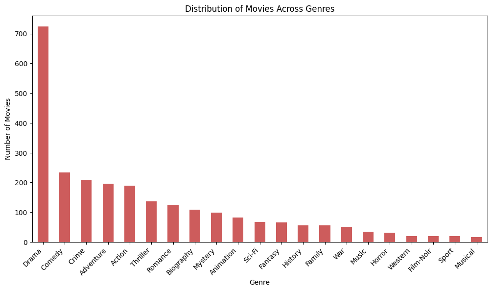

```python
import matplotlib.pyplot as plt

# Assuming you have a DataFrame with one-hot-encoded genres
# For example: df[['Action', 'Adventure', 'Comedy', 'Drama', ...]]

# Sum the binary values for each genre
genre_counts = df_genre_plot.iloc[:,:].sum()  # Assuming genre columns start at index 17

# Plotting the histogram
plt.figure(figsize=(12, 6))
genre_counts.sort_values(ascending=False).plot(kind='bar', color='indianred')
plt.title('Distribution of Movies Across Genres')
plt.xlabel('Genre')
plt.ylabel('Number of Movies')
plt.xticks(rotation=45, ha='right')
plt.show()
```

```python
# Count the genres for each movie
df_movies['Genre_Count'] = df_movies['Genre'].apply(lambda x: len(x.split(',')))
```

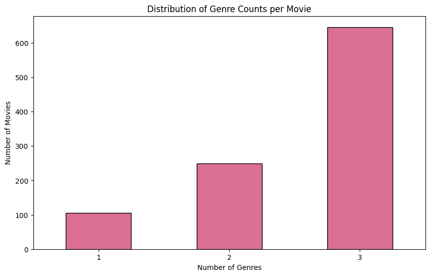

```python
# How many genres do the movies have
# Count the occurrences of each unique genre count
genre_count_distribution = df_movies['Genre_Count'].value_counts().sort_index()

# Plotting the bar plot
plt.figure(figsize=(10, 6))
genre_count_distribution.plot(kind='bar', color='palevioletred', edgecolor='black')
plt.title('Distribution of Genre Counts per Movie')
plt.xlabel('Number of Genres')
plt.ylabel('Number of Movies')
plt.xticks(rotation=0)
plt.show()
```

```python
# Concatenate horizontally
df_combined = pd.concat([df_movies, df_genre_plot], axis=1)
```

## Some illustrations

After looking at the genres, we generate illustrations for the remaining data columns. We will go through each of the seven plots in order.

1. **Release year:** It becomes clear that there are significantly more newer movies. This might be related to the increasing number of movies released each year as well as to the changing expectations of movie goers. We note here that this dataset is very restricted in that we are only considering movies with high ratings. This makes it hard to distinguish which factor is more important here.
2. **Certificate:** A surprising amount of movies are R rated/A rated. This suggests that while these movies typically generate smaller box office, they can generate high ratings.
3. **Runtime:** The runtime almost follows a normal distribution with a tilt towards longer movies.
4. **IMDB Rating:** The ratings have been cut off at roughly 7.5, due to the nature of the dataset.
5. **Meta-Score:** Unlike the IMDB ratings (from the public), the Meta-Score generated based on critics' opinions have not been cut off. They are almost normally distributed.
6. **No of votes:** The number of votes is roughly exponentially distributed (as one might expect).
7. **Gross:** The box office is roughly exponentially distributed (as one might expect).

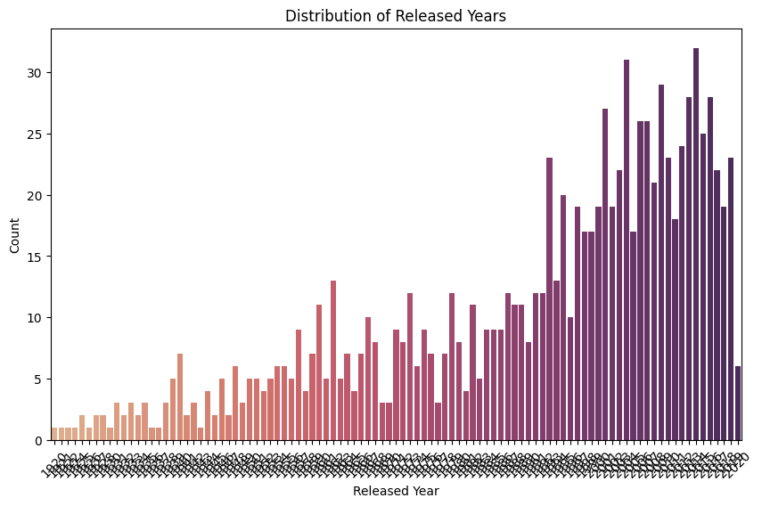

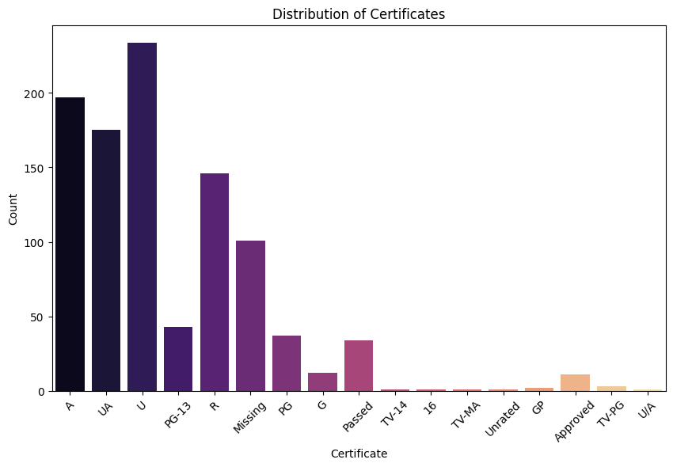

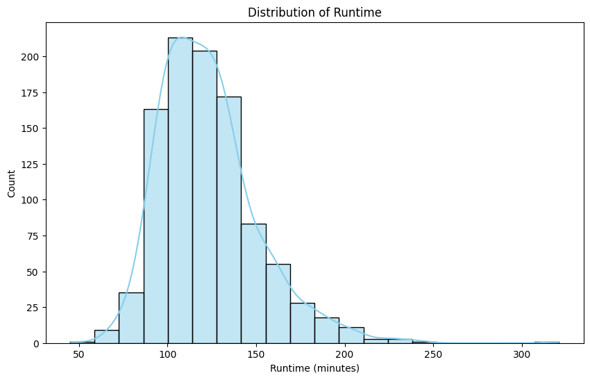

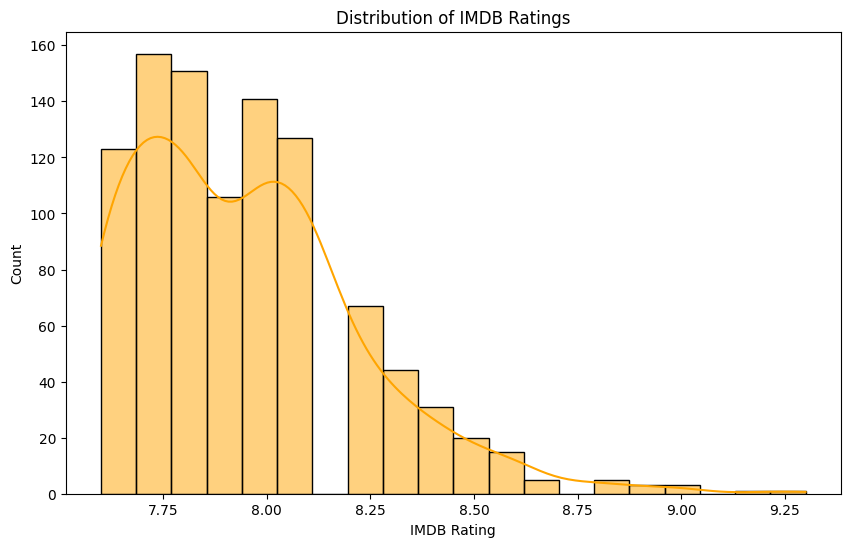

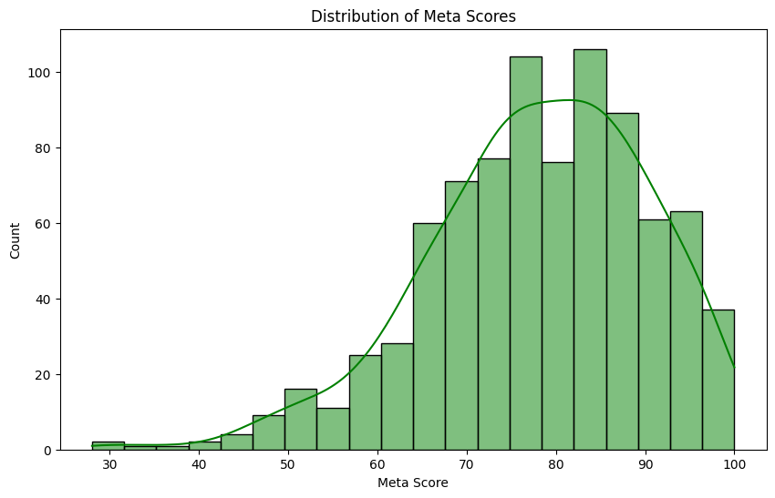

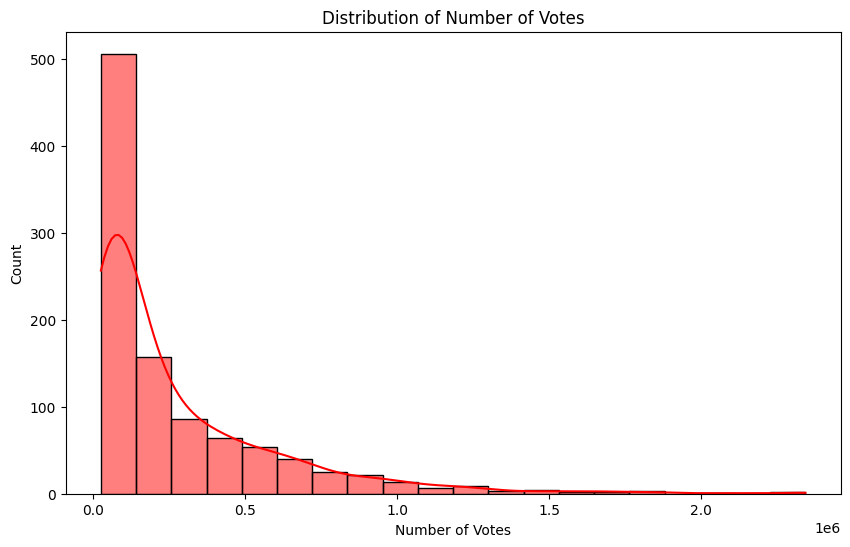

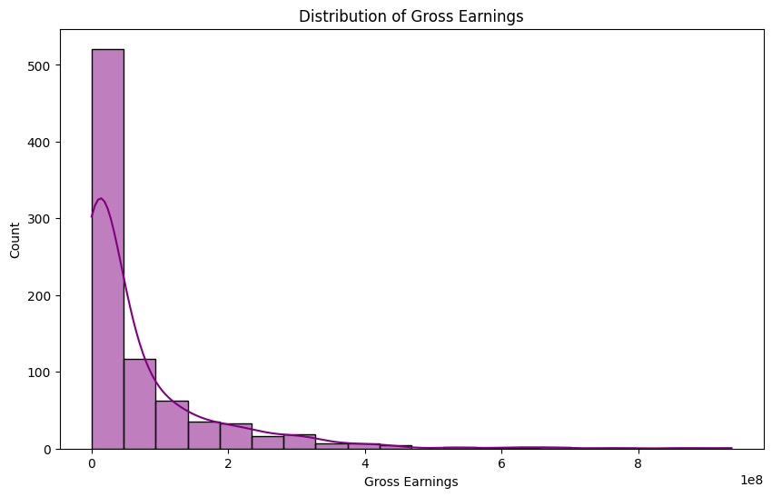

```python
import matplotlib.pyplot as plt
import seaborn as sns

# Load your dataset
# df = pd.read_csv('your_dataset.csv')

# Drop rows with missing values for the purpose of illustration
df_cleaned = df_movies

# Plotting the features

# 1. Released_Year
plt.figure(figsize=(10, 6))
sns.countplot(x='Released_Year', data=df_movies, palette='flare')
plt.title('Distribution of Released Years')
plt.xlabel('Released Year')
plt.ylabel('Count')
plt.xticks(rotation=45)
plt.show()

# 2. Certificate
plt.figure(figsize=(10, 6))
sns.countplot(x='Certificate', data=df_cleaned, palette='magma')
plt.title('Distribution of Certificates')
plt.xlabel('Certificate')
plt.ylabel('Count')
plt.xticks(rotation=45)
plt.show()

# 3. Runtime
plt.figure(figsize=(10, 6))
sns.histplot(df_cleaned['Runtime'], bins=20, kde=True, color='skyblue')
plt.title('Distribution of Runtime')
plt.xlabel('Runtime (minutes)')
plt.ylabel('Count')
plt.show()

# 5. IMDB_Rating
plt.figure(figsize=(10, 6))
sns.histplot(df_cleaned['IMDB_Rating'], bins=20, kde=True, color='orange')
plt.title('Distribution of IMDB Ratings')
plt.xlabel('IMDB Rating')
plt.ylabel('Count')
plt.show()

# 6. Meta_score
plt.figure(figsize=(10, 6))
sns.histplot(df_cleaned['Meta_score'].dropna(), bins=20, kde=True, color='green')
plt.title('Distribution of Meta Scores')
plt.xlabel('Meta Score')
plt.ylabel('Count')
plt.show()

# 7. No_of_Votes
plt.figure(figsize=(10, 6))
sns.histplot(df_cleaned['No_of_Votes'], bins=20, kde=True, color='red')
plt.title('Distribution of Number of Votes')
plt.xlabel('Number of Votes')
plt.ylabel('Count')
plt.show()

# 8. Gross
plt.figure(figsize=(10, 6))
sns.histplot(df_cleaned['Gross'].dropna(), bins=20, kde=True, color='purple')
plt.title('Distribution of Gross Earnings')
plt.xlabel('Gross Earnings')
plt.ylabel('Count')
plt.show()
```

## Correlations

The next step was to generate a correlation heat map. Some very interesting observations by strength of correlation:

1. No of votes and box office are positively correlated. This makes sense as more popular movies get more votes.
2. No of votes and IMDB score are positively correlated. If a movie has a high IMDB score more people are interested in watching the movie.
3. Older movies have a higher meta score and slightly higher IMDB score. This might be due to a certain selection bias against older movies which makes only 'good' movies become 'classics' with high critical acclaim.
4. Higher IMDB rating means higher meta score. The opinion of the public and of critics has a relatively high correlation.
5. Newer films have higher box office and more votes.
6. Longer runtime gives higher IMDB rating. This might be due to (7.)
7. Newer films are longer.
8. Longer runtime means more votes and higher box office. This is probably due to (7.)

[figure not shown]

```python
import seaborn as sns
import matplotlib.pyplot as plt

# Assuming df_movies is your DataFrame with numerical features
# Selecting only numerical columns
numerical_columns = df_movies.drop(['Gross_fillna','Meta_score_fillna'],axis=1).select_dtypes(include=['float64', 'int64'])

# Compute the correlation matrix
correlation_matrix = numerical_columns.corr()

# Create a heatmap
plt.figure(figsize=(12, 10))
sns.heatmap(correlation_matrix, annot=True, cmap='rocket', fmt=".2f", linewidths=0.5)
plt.title('Correlation Heatmap of Numerical Features')
plt.show()
```

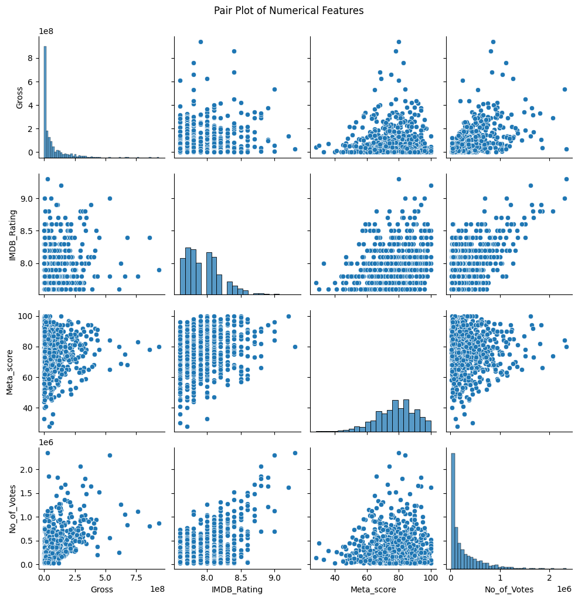

```python
# An additional illustration of the relationship between the different features
sns.pairplot(df_movies[['Gross', 'IMDB_Rating', 'Meta_score', 'No_of_Votes']])
plt.suptitle('Pair Plot of Numerical Features', y=1.02)
plt.show()
```

## On directors

After illustrating the numerical features, we compare the different directors and rank them by the number of top 1000 movies. Alfred Hitchcock has the largest amount of movies. For our later analysis, this means that enjoying a movie by Alfred Hitchcock provides only a small amount of information for the recommendation system, compared to liking a movie by a director with only three movies.

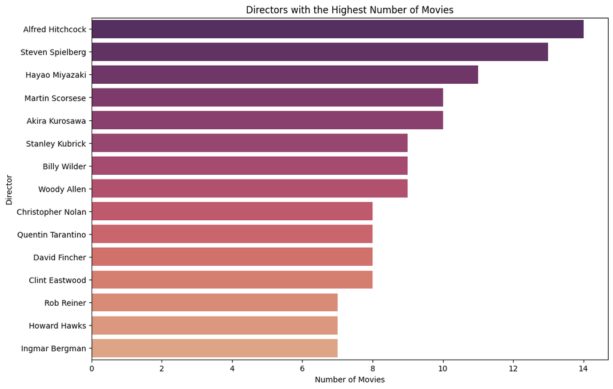

```python
# Assuming df_movies is your DataFrame
directors_movie_count = df_movies['Director'].value_counts().nlargest(15)

plt.figure(figsize=(12, 8))
sns.barplot(x=directors_movie_count.values, y=directors_movie_count.index, palette='flare_r')
plt.title('Directors with the Highest Number of Movies')
plt.xlabel('Number of Movies')
plt.ylabel('Director')
plt.show()
```

# On Actors

Similarly, we rank the actors with the largest amount of movies. Here, we see that Robert De Niro contributed to most movies. So, liking a movie with Robert De Niro will not provide as much information as liking a movie with Scarlett Johannsen (in 9 movies).

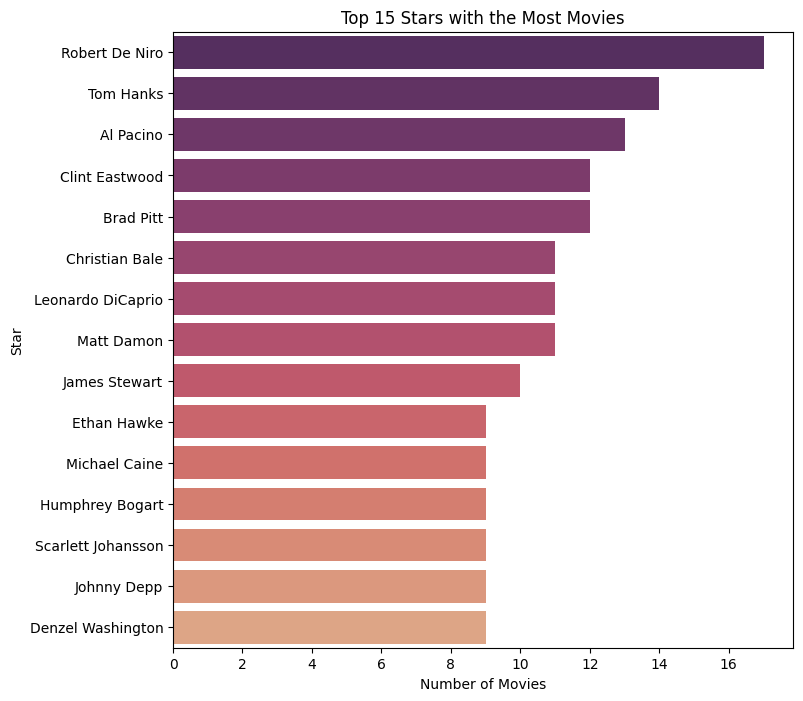

```python
# Save the number of top movies by stars
top_stars_movie_count = df_movies[['Star1', 'Star2', 'Star3', 'Star4']].stack().value_counts()

# Extracting top 10 stars based on the number of movies
top_stars = top_stars_movie_count.nlargest(15)

# Plotting
plt.figure(figsize=(8, 8))
sns.barplot(x=top_stars.values, y=top_stars.index, palette='flare_r')
plt.title('Top 15 Stars with the Most Movies')
plt.xlabel('Number of Movies')
plt.ylabel('Star')
plt.show()
```

## Natural Language Processing: Overview

In the next step, we preprocess the movie overview. This data consists of a texts describing the content of the movie. It will be an important factor in the content-based recommendation system.

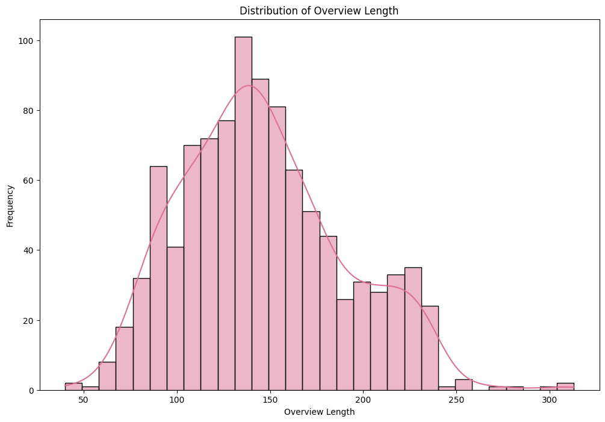

```python
import matplotlib.pyplot as plt
import seaborn as sns

# Assuming df_movies is your DataFrame

# Create a new column 'Overview_Length' with the length of each overview
df_movies['Overview_Length'] = df_movies['Overview'].apply(lambda x: len(str(x)))

# Plotting
plt.figure(figsize=(12, 8))
sns.histplot(df_movies['Overview_Length'], bins=30, kde=True, color='palevioletred')
plt.title('Distribution of Overview Length')
plt.xlabel('Overview Length')
plt.ylabel('Frequency')
plt.show()
```

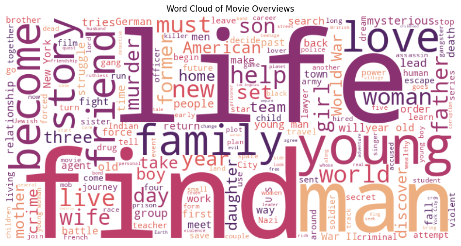

```python
from wordcloud import WordCloud, STOPWORDS
import matplotlib.pyplot as plt

# Assuming df_movies is your DataFrame

# Concatenate all 'Overview' texts into a single string
all_overviews = ' '.join(df_movies['Overview'].dropna())

# Define custom stopwords
custom_stopwords = set(STOPWORDS)
custom_stopwords.update(['one', 'two'])  # Add words to exclude

# Generate a word cloud with custom stopwords
wordcloud = WordCloud(width=800, height=400, background_color='white', colormap='flare',stopwords=custom_stopwords).generate(all_overviews)

# Plotting the word cloud
plt.figure(figsize=(12, 8))
plt.imshow(wordcloud, interpolation='bilinear')
plt.axis('off')
plt.title('Word Cloud of Movie Overviews')
plt.show()
```

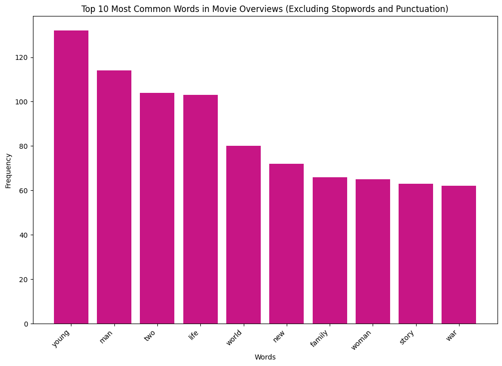

```python
import nltk
from nltk.corpus import stopwords
from nltk.tokenize import word_tokenize
from string import punctuation
from collections import Counter
import matplotlib.pyplot as plt

# Download NLTK stopwords (if not already downloaded)
nltk.download('stopwords')

# Assuming df_movies is your DataFrame

# Concatenate all 'Overview' texts into a single string
all_overviews = ' '.join(df_movies['Overview'].dropna())

# Tokenize the text into words
words = word_tokenize(all_overviews)

# Filter out stopwords, common punctuation marks, and 's'
stop_words = set(stopwords.words('english'))
filtered_words = [word.lower() for word in words if word.lower() not in stop_words and word.lower() not in punctuation and word.lower() != "'s"]

# Count the frequency of each word
word_freq = Counter(filtered_words)

# Get the most common words and their frequencies
top_words = word_freq.most_common(10)  # Change the number as needed

# Plotting the bar plot
plt.figure(figsize=(12, 8))
plt.bar([word[0] for word in top_words], [word[1] for word in top_words], color='#C71585')
plt.title('Top 10 Most Common Words in Movie Overviews (Excluding Stopwords and Punctuation)')
plt.xlabel('Words')
plt.ylabel('Frequency')
plt.xticks(rotation=45, ha='right')  # Rotate x-axis labels for better readability
plt.show()
```

# Recommendation System

```python
import pandas as pd
from sklearn.feature_extraction.text import TfidfVectorizer
from sklearn.metrics.pairwise import cosine_similarity

# Assuming 'Overview', 'Director', and 'Star' are features
features = ['Overview', 'Director', 'Genre','Star1','Star2','Star3','Star4']

# Define weights for each feature
weights = {'Overview': 1, 'Director': 0.3, 'Genre': 0.3,'Star1':0.05,'Star2':0.05,'Star3':0.05,'Star4':0.05}

# Fill NaN values with an empty string
df_movies[features] = df_movies[features].fillna('')

# Combine text features into a single column
df_movies['Combined_Text'] = df_movies[features].apply(lambda row: ' '.join(row), axis=1)

# Fit the TfidfVectorizer to the combined text
tfidf_vectorizer = TfidfVectorizer()
combined_tfidf_matrix = tfidf_vectorizer.fit_transform(df_movies['Combined_Text'])

# Function to transform individual features based on the fitted vectorizer and apply weights
def transform_feature(feature):
    feature_tfidf_matrix = tfidf_vectorizer.transform(df_movies[feature])
    return feature_tfidf_matrix * weights[feature]

# Transform individual features
tfidf_matrices = {feature: transform_feature(feature) for feature in features}

# Combine individual feature matrices
combined_tfidf_matrix = sum(tfidf_matrices.values())

# Calculate cosine similarity
cosine_sim = cosine_similarity(combined_tfidf_matrix, combined_tfidf_matrix)

# Function for movie recommendations
def get_recommendations(input_movies):
    input_indices = []
    for movie_title in input_movies:
        idx = df_movies[df_movies['Series_Title'] == movie_title].index
        if not idx.empty:
            input_indices.append(idx[0])

    if not input_indices:
        return "No matches found for input movies."

    sim_scores = cosine_sim[input_indices].sum(axis=0)

    # Exclude input movies from recommendations
    exclude_indices = np.array(input_indices)
    sim_scores[exclude_indices] = -1

    # Get top recommendations
    movie_indices = sim_scores.argsort()[::-1][:5]
    return df_movies['Series_Title'].iloc[movie_indices]

# Example usage
input_movies = ['The Matrix', 'Dunkirk', 'The Lord of the Rings: The Fellowship of the Ring']
recommendations = get_recommendations(input_movies)
print(recommendations)
```

```
5      The Lord of the Rings: The Return of the King
63                             The Dark Knight Rises
496                            Letters from Iwo Jima
705                                  The Longest Day
179                                 The Great Escape
Name: Series_Title, dtype: object
```

# Future Directions

While this system can already find similar movies, it does not take into account many movies due to the size of the data set. Future work should take into account a larger dataset. Additionally, we currently have recommendation systems that are either based solely on content-based or collaborative filtering. In the future, I plan to use a larger dataset with both content-based and collaborative data to build a hybrid recommendation system.